# March 25, 2025

# CIS 241

# Take-Home Test 2

*This test is a bit different from normal workshop assignments. On the tests you should make sure that all the writing and code is your own. If you borrow code from online or another source, be sure to cite that source by adding a comment to the code explaining where it came from. Likewise, everything in the written portion should be in your own words, and you should not be collaborating with other students. You're free to use any of the slideshows and other course resources, as well as the previous workshops. If you have questions about any of this, feel free to reach out to me.*

You'll work again with a dataset that includes information about food waste across the world. The data is from the dataviz website [Information is Beautiful](https://informationisbeautiful.net/data), which collected the information from, among other sources, the [United Nations Environment Programme's Food Waste Index Report](https://www.unep.org/resources/report/unep-food-waste-index-report-2021) from 2021. Their website describes the data collection process at length, including this summary: "Reducing food waste at retail, food service and household level can provide multi-faceted benefits for both people and the planet. However, the true scale of food waste and its impacts have not been well understood until now. As such, the opportunities provided by food waste reduction have remained largely untapped and under-exploited. If we want to get serious about tackling food waste, we need to increase efforts to measure food and inedible parts wasted at retail and consumer level and track food waste generation in kilograms per capita at country level."

**If you have questions about the data or any of the column names, remember to refer back to the links and description above. You can also come to me with questions about the dataset—for the purposes of this assignment, I am your data analysis client.**

You can load in the data using the following link: https://jrladd.com/CIS241/data/foodwaste.csv

**Keep in mind that the writing portions of this quiz are just as important as the coding portions. Make sure you take the time to interpret your results and visualizations *fully and accurately*.**

**The goal of this assignment is to create two models that can accurately predict numeric or categorical aspects of food waste.**

To complete the assignment do the following:

1. Write a few sentences of introduction explaining the data and what you will do in this report. Load in the data and perform any necessary data wrangling. (Hint: you might consider some of the data wrangling steps you took in the last assignment.) (5 pts)
2. Run some Exploratory Data Analysis, with at least two visualizations, interpreted completely and accurately. Explain how these visualizations help you understand the models you will construct. (20 pts)
3. Create a regression model, using a method of your choice that predicts the combined food waste (in kg per capita per year) using *only* the food waste in tonnes and the region as your predictors. You may choose from linear regression (multivariate), KNN regression, or Random Forest regression. *Explain why you chose the model you did.* **Make sure all appropriate data preparation and validation steps are complete**. *Note: There are some outliers in this data, so consider what to do with them before you continue your modeling process.* (30 pts)
4. If you wanted to create a model to classify a country by its confidence level, it would not be a good idea, statistically speaking, to do so. Why not? Run any EDA processes you need to answer this question, and give a complete and accurate response. (5 pts)
5. First, filter your data to include only the two regions with the most countries: Sub-saharan Africa, and Latin America and the Caribbean. Create a classification model, using a method of your choice, that predicts whether a country belongs to one of these two regions. You may choose from: Logistic Regression, Naive Bayes, KNN classification, or Random Forest classification. You may not choose the same type of model as you did for the previous step, e.g. if you chose KNN regression then you cannot use KNN classification here. *Explain why you chose the model you did.* **Make sure all appropriate data preparation and validation steps are complete**: *note that the predictors you need and the steps you take will likely be different for whichever model you choose*. (30 pts)
6. Write a conclusion that explains your findings and suggests some possible next steps. (10 pts)

***n.b. If you're having memory issues and your kernel is shutting down, you can separate the assignment into two separate notebooks. ALL steps of your regression model must be in one notebook, and ALL steps of your classification model must be in one notebook. In this case you would turn in two HTML files, and everything should be clearly labeled and easy to follow.***

Your report **must** include the following:

- A written introduction and conclusion.
- Markdown headings that separate the sections of your report.
- Clear explanations of each step in your process, in markdown and code comments.
- Full written interpretations of every model, visualization, and statistical output.

# 1. Introduction and Data Wrangling

This dataset provides a comprehensive view of the amount of food waste each country in the world produces measured in both tonnes and kilograms per capita every year. It further classifies the amount of food waste into 3 separate categories, including household estimates, retail estimates, and food service estimates. These 3 categories have separate figures in kg/capita/year and tonnes/year.

Each row in this dataset represents a specific country in the World and their statistics concerning food waste. The rows are organized in alphabetical order. Specifically, the first letter of each country name organizes the data. Each column represents the features of a country's statistical data, as well as where the data came from.

In addition to the country's name and statistics, the countries are also categorized by their world region, which include Southeastern Asia, Southern Europe, Northern Africa, etc. In addition, each country is given a specific M49 code, which refers to the UN Standard Country (or Area Codes) for Statistical Use, a system developed by the United Nations Statistics Division for classifying and identifying countries and areas for statistical purposes. The M49 provides a unique (3-digit) numerical code for each country. Finally, the dataset provides confidence levels in these estimates, ranging from "Very Low Confidence" to "High Confidence".

In this report, I will use a regression model to predict if the categories that measure food waste in tonnes (household estimate, retail estimate, and food service estimate) as well as a country's region influence the total amount of food wasted (measured in kg/capita/year). I will also create a classification model to predict if a certain country falls under one of the following two regions: Sub-saharan Africa and Latin America and the Caribbean.

```python
import pandas as pd # Data Analysis
import numpy as np # Numerical Calculations
import altair as alt # Data Visualization

alt.data_transformers.enable("vegafusion")
```

```
DataTransformerRegistry.enable('vegafusion')
```

```python
food = pd.read_csv("https://jrladd.com/CIS241/data/foodwaste.csv")
food
```

|  | Country | combined figures (kg/capita/year) | Household estimate (kg/capita/year) | Household estimate (tonnes/year) | Retail estimate (kg/capita/year) | Retail estimate (tonnes/year) | Food service estimate (kg/capita/year) | Food service estimate (tonnes/year) | Confidence in estimate | M49 code | Region | Source |
| --- | --- | --- | --- | --- | --- | --- | --- | --- | --- | --- | --- | --- |
| 0 | Afghanistan | 126 | 82 | 3,109,153 | 16 | 594,982 | 28 | 1,051,783 | Very Low Confidence | 4 | Southern Asia | https://www.unep.org/resources/report/unep-foo... |
| 1 | Albania | 127 | 83 | 238,492 | 16 | 45,058 | 28 | 79,651 | Very Low Confidence | 8 | Southern Europe | https://www.unep.org/resources/report/unep-foo... |
| 2 | Algeria | 135 | 91 | 3,918,529 | 16 | 673,360 | 28 | 1,190,335 | Very Low Confidence | 12 | Northern Africa | https://www.unep.org/resources/report/unep-foo... |
| 3 | Andorra | 123 | 84 | 6,497 | 13 | 988 | 26 | 1,971 | Low Confidence | 20 | Southern Europe | https://www.unep.org/resources/report/unep-foo... |
| 4 | Angola | 144 | 100 | 3,169,523 | 16 | 497,755 | 28 | 879,908 | Very Low Confidence | 24 | Sub-Saharan Africa | https://www.unep.org/resources/report/unep-foo... |
| ... | ... | ... | ... | ... | ... | ... | ... | ... | ... | ... | ... | ... |
| 209 | Venezuela (Boliv. Rep. of) | 116 | 72 | 2,065,461 | 16 | 445,994 | 28 | 788,407 | Very Low Confidence | 862 | Latin America and the Caribbean | https://www.unep.org/resources/report/unep-foo... |
| 210 | Viet Nam | 120 | 76 | 7,346,717 | 16 | 1,508,689 | 28 | 2,666,991 | Very Low Confidence | 704 | South-eastern Asia | https://www.unep.org/resources/report/unep-foo... |
| 211 | Yemen | 148 | 104 | 3,026,946 | 16 | 456,099 | 28 | 806,270 | Very Low Confidence | 887 | Western Asia | https://www.unep.org/resources/report/unep-foo... |
| 212 | Zambia | 122 | 78 | 1,391,729 | 16 | 279,350 | 28 | 493,822 | Very Low Confidence | 894 | Sub-Saharan Africa | https://www.unep.org/resources/report/unep-foo... |
| 213 | Zimbabwe | 144 | 100 | 1,458,564 | 16 | 229,059 | 28 | 404,920 | Very Low Confidence | 716 | Sub-Saharan Africa | https://www.unep.org/resources/report/unep-foo... |

214 rows × 12 columns

The first step I took when wrangling the data was to rename the columns into more computer-friendly terms. I did this because these column names will be easier to work with.

```python
food = food.rename(columns={"combined figures (kg/capita/year)":"combined_figures", "M49 code":"Code", "Household estimate (kg/capita/year)": "Household_estimate_kgCapita","Household estimate (tonnes/year)": "Household_estimate_tonnes", "Retail estimate (kg/capita/year)": "Retail_estimate_kgCapita","Retail estimate (tonnes/year)": "Retail_estimate_tonnes", "Food service estimate (kg/capita/year)": "Food_service_estimate_kgCapita","Food service estimate (tonnes/year)": "Food_service_estimate_tonnes", "Confidence in estimate":"Confidence"})
```

The next step I took was to reclassify the statistics that measured food waste in tonnnes because into integers because they were originally considered as "objects" when the dataset was read in. This is because the original format included the `,` character, which caused the data to be read incorrectly and could potentially cause future errors in the code.

```python
# This chunk of code removes each "," character from the three incorrect data columns so that it can be converted to an integer without showing NaN
food["Household_estimate_tonnes"] = food["Household_estimate_tonnes"].replace(",","",regex=True)
food = food.assign(Household_estimate_tonnes = pd.to_numeric(food["Household_estimate_tonnes"], errors="coerce"))
food["Retail_estimate_tonnes"] = food["Retail_estimate_tonnes"].replace(",","",regex=True)
food = food.assign(Retail_estimate_tonnes = pd.to_numeric(food["Retail_estimate_tonnes"], errors="coerce"))
food["Food_service_estimate_tonnes"] = food["Food_service_estimate_tonnes"].replace(",","",regex=True)
food = food.assign(Food_service_estimate_tonnes = pd.to_numeric(food["Food_service_estimate_tonnes"], errors="coerce"))
```

```python
food
```

|  | Country | combined_figures | Household_estimate_kgCapita | Household_estimate_tonnes | Retail_estimate_kgCapita | Retail_estimate_tonnes | Food_service_estimate_kgCapita | Food_service_estimate_tonnes | Confidence | Code | Region | Source |
| --- | --- | --- | --- | --- | --- | --- | --- | --- | --- | --- | --- | --- |
| 0 | Afghanistan | 126 | 82 | 3109153 | 16 | 594982 | 28 | 1051783 | Very Low Confidence | 4 | Southern Asia | https://www.unep.org/resources/report/unep-foo... |
| 1 | Albania | 127 | 83 | 238492 | 16 | 45058 | 28 | 79651 | Very Low Confidence | 8 | Southern Europe | https://www.unep.org/resources/report/unep-foo... |
| 2 | Algeria | 135 | 91 | 3918529 | 16 | 673360 | 28 | 1190335 | Very Low Confidence | 12 | Northern Africa | https://www.unep.org/resources/report/unep-foo... |
| 3 | Andorra | 123 | 84 | 6497 | 13 | 988 | 26 | 1971 | Low Confidence | 20 | Southern Europe | https://www.unep.org/resources/report/unep-foo... |
| 4 | Angola | 144 | 100 | 3169523 | 16 | 497755 | 28 | 879908 | Very Low Confidence | 24 | Sub-Saharan Africa | https://www.unep.org/resources/report/unep-foo... |
| ... | ... | ... | ... | ... | ... | ... | ... | ... | ... | ... | ... | ... |
| 209 | Venezuela (Boliv. Rep. of) | 116 | 72 | 2065461 | 16 | 445994 | 28 | 788407 | Very Low Confidence | 862 | Latin America and the Caribbean | https://www.unep.org/resources/report/unep-foo... |
| 210 | Viet Nam | 120 | 76 | 7346717 | 16 | 1508689 | 28 | 2666991 | Very Low Confidence | 704 | South-eastern Asia | https://www.unep.org/resources/report/unep-foo... |
| 211 | Yemen | 148 | 104 | 3026946 | 16 | 456099 | 28 | 806270 | Very Low Confidence | 887 | Western Asia | https://www.unep.org/resources/report/unep-foo... |
| 212 | Zambia | 122 | 78 | 1391729 | 16 | 279350 | 28 | 493822 | Very Low Confidence | 894 | Sub-Saharan Africa | https://www.unep.org/resources/report/unep-foo... |
| 213 | Zimbabwe | 144 | 100 | 1458564 | 16 | 229059 | 28 | 404920 | Very Low Confidence | 716 | Sub-Saharan Africa | https://www.unep.org/resources/report/unep-foo... |

214 rows × 12 columns

# Step 2: Exploratory Data Analysis

In order to understand my regression model, I have chosen to begin with 3 scatter plots. These will visually display the relationship between the 3 categories of food waste (measured in kg/capita/year) and `Combined figures (kg/capita/year)`. By using these scatter plots, I can determine which of the 3 categories has the strongest correlation to `Combined figures`.

Note: I have chosen to use kg/capita/year as my unit of measurement for the scatter plots because the combined figures only has that measurement, and using tonnes for the subcategories would make the scatter plots unreadable.

```python
alt.Chart(food, title="Household Estimates (kg/capita/year) vs Combined Figures (kg/capita/year)").mark_point().encode(
    x=alt.X("Household_estimate_kgCapita:Q",title="Household Estimate (kg/capita/year)").scale(zero=False),
    y=alt.Y("combined_figures:Q",title="Combined Figures (kg/capita/year")
)
```

[interactive chart not shown]

My first scatter plot displays the relationship between `Household estimate (kg/capita/year)` vs `Combined figures (kg/capita/year)`. As you can see, the blue dots follow a straight line pattern, suggesting that there is a strong, positive correlation between the two variables. This means that Household estimates have a very high influence on the Combined figures of food wasted in kg/capita/year. Some blue dots are located well outside of the straight line pattern, meaning that they are outliers to the data. These could be due to incorrect data entry, an unexpected pattern in the data, or an extreme value.

```python
alt.Chart(food, title="Retail Estimates (kg/capita/year) vs Combined Figures (kg/capita/year)").mark_point().encode(
    x=alt.X("Retail_estimate_kgCapita:Q",title="Retail Estimate (kg/capita/year)").scale(zero=False),
    y=alt.Y("combined_figures:Q",title="Combined Figures (kg/capita/year")
)
```

[interactive chart not shown]

My second scatter plot presents the correlation between `Retail estimate (kg/capita/year)` and `Combined figures (kg/capita/year)`. Based on the blue dots, there appears to be little to no correlation between the two variables. The straight vertical line indicates that there is no correlation/relationship between the two variables, meaning that one variable does not affect the other. Therefore, I can conclude that Retail estimates have little to no impact on the combined figures of wasted food.

```python
alt.Chart(food, title="Household Estimates (kg/capita/year) vs Combined Figures (kg/capita/year)").mark_point().encode(
    x=alt.X("Food_service_estimate_kgCapita:Q",title="Food Service Estimate (kg/capita/year)").scale(zero=False),
    y=alt.Y("combined_figures:Q",title="Combined Figures (kg/capita/year")
)
```

[interactive chart not shown]

My final scatter plot represents the correlation between `Food service estimate (kg/capita/year)` vs `Combined figures (kg/capita/year)`. Much like the previous scatter plot, there appears to be little to no correlation between the two variables. The straight vertical line indicates that there is no correlation/relationship between the two variables, meaning that one variable does not affect the other. Therefore, I can conclude that Food service estimates have little to no impact on the combined figures of wasted food.

To also better understand my classification model, I will need to create a bar plot to determine which country belongs to either the "Sub-Saharan Africa" or the "Latin America and the Caribbean" based on food waste statistics. This will help me compare how well my classification model will perform because the visualization contains the real data.

Note that in order to create a visualization with only two regions, I need to create a subset of the `food` DataFrame such that only countries that are located in "Sub-Saharan Africa" or "Latin America and the Caribbean" are included. This will also help me with my classificaiton model as I will not have to create a subset of the `food` DataFrame later on.

```python
food_subset = food[(food.Region == "Sub-Saharan Africa") | (food.Region=="Latin America and the Caribbean")]
```

```python
alt.Chart(food_subset, title="Food Waste Statistics in countries located in Sub-Saharan Africa and Latin America and the Caribbean").mark_bar().encode(
    x=alt.X("Country:N").scale(clamp=True),
    y=alt.Y("combined_figures:Q",title="Combined Figures (kg/capita/year)"),
    color=alt.Color("Region:N")
)
```

[interactive chart not shown]

This bar plot represents all the countries mentioned in the United Nations Environment Program's Food Waste Index Report and categorizes all of the countries that meet the criteria to be categorized as either "Sub-Saharan Africa" or "Latin America and the Caribbean". According to the bar plot, 47 countries were considere part of the "Sub-Saharan Africa" region, whereas only 43 countries met the criteria to be categorized as part of the "Latin America and the Caribbean" region. This means that countries in the "Sub-Saharan Africa" region appear to waste more food than countries in the "Latin America and the Caribbean" region.

```python
food
```

|  | Country | combined_figures | Household_estimate_kgCapita | Household_estimate_tonnes | Retail_estimate_kgCapita | Retail_estimate_tonnes | Food_service_estimate_kgCapita | Food_service_estimate_tonnes | Confidence | Code | Region | Source |
| --- | --- | --- | --- | --- | --- | --- | --- | --- | --- | --- | --- | --- |
| 0 | Afghanistan | 126 | 82 | 3109153 | 16 | 594982 | 28 | 1051783 | Very Low Confidence | 4 | Southern Asia | https://www.unep.org/resources/report/unep-foo... |
| 1 | Albania | 127 | 83 | 238492 | 16 | 45058 | 28 | 79651 | Very Low Confidence | 8 | Southern Europe | https://www.unep.org/resources/report/unep-foo... |
| 2 | Algeria | 135 | 91 | 3918529 | 16 | 673360 | 28 | 1190335 | Very Low Confidence | 12 | Northern Africa | https://www.unep.org/resources/report/unep-foo... |
| 3 | Andorra | 123 | 84 | 6497 | 13 | 988 | 26 | 1971 | Low Confidence | 20 | Southern Europe | https://www.unep.org/resources/report/unep-foo... |
| 4 | Angola | 144 | 100 | 3169523 | 16 | 497755 | 28 | 879908 | Very Low Confidence | 24 | Sub-Saharan Africa | https://www.unep.org/resources/report/unep-foo... |
| ... | ... | ... | ... | ... | ... | ... | ... | ... | ... | ... | ... | ... |
| 209 | Venezuela (Boliv. Rep. of) | 116 | 72 | 2065461 | 16 | 445994 | 28 | 788407 | Very Low Confidence | 862 | Latin America and the Caribbean | https://www.unep.org/resources/report/unep-foo... |
| 210 | Viet Nam | 120 | 76 | 7346717 | 16 | 1508689 | 28 | 2666991 | Very Low Confidence | 704 | South-eastern Asia | https://www.unep.org/resources/report/unep-foo... |
| 211 | Yemen | 148 | 104 | 3026946 | 16 | 456099 | 28 | 806270 | Very Low Confidence | 887 | Western Asia | https://www.unep.org/resources/report/unep-foo... |
| 212 | Zambia | 122 | 78 | 1391729 | 16 | 279350 | 28 | 493822 | Very Low Confidence | 894 | Sub-Saharan Africa | https://www.unep.org/resources/report/unep-foo... |
| 213 | Zimbabwe | 144 | 100 | 1458564 | 16 | 229059 | 28 | 404920 | Very Low Confidence | 716 | Sub-Saharan Africa | https://www.unep.org/resources/report/unep-foo... |

214 rows × 12 columns

# Step 3: Regression Model

I have chosen to use linear regression as my regression model because it is the simplest to work with and will provide the most accurate results.

```python
# These import lines are needed to run the regression and classification models
from sklearn.model_selection import train_test_split, cross_val_score
# These replace the r-squared score and RMSE
from sklearn.metrics import mean_squared_error, r2_score
# You could put these all on one line
from sklearn.metrics import RocCurveDisplay, confusion_matrix, classification_report

# You'll also need matplotlib this time
import matplotlib.pyplot as plt
```

```python
from sklearn.linear_model import LinearRegression
```

I completed all data preparation in the previous Data Wrangling section. However, I will need to complete some validation steps before running the regression model. Specifically, I will need to test for multicollinearity. This is because multicollinearity confuses the model and could even result in false predictions.

Since I am predicting combined food waste using food waste measured in tonnes and a country's region, my target variable will be `combined_figures`, and my potential predictors will be `Household_estimate_tonnes`, `Retail_estimate_tonnes`, `Food_service_estimate_tonnes`, and `Region`.

```python
target = "combined_figures"
potential_predictors = ["Household_estimate_tonnes", "Retail_estimate_tonnes", "Food_service_estimate_tonnes", "Region"]
```

To test for multicolinearity, I have chosen to create a heatmap of all of the numerical potential predictors using the correlation coefficients between two of them (Household estimate, Retail estimate, and food service estimate, all measured in tonnes/year).

```python
food_corr = food[potential_predictors].corr(numeric_only=True).stack().reset_index().rename(columns={0:"corr","level_0":"var1","level_1":"var2"})
food_corr
base = alt.Chart(food_corr, title="Food Correlation Matrix").mark_rect().encode(
    x=alt.X("var1:N",title=None),
    y=alt.Y("var2:N",title=None),
    color=alt.Color("corr",title="Correlation coefficient").scale(scheme='blueorange')
).properties(width=300,height=300)

text = base.mark_text(baseline='middle').encode(
    alt.Text('corr:Q',format=".2f"),
    color=alt.condition(
        (alt.datum.corr < -0.5) | (alt.datum.corr > 0.5),
        alt.value('white'),
        alt.value('black')
    )
)

base+text
```

[interactive chart not shown]

This heatmap shows that all 3 numerical predictor variables (Household estimate, Retail estimate, and food service estimate, all measured in tonnes/year) have multicollinearity. This means I must remove all but one of these variables in order to create a better model. In this case, I am choosing household estimates as they have the highest influence on the combined figures.

```python
predictors = ["Household_estimate_tonnes","Region"]
```

I used this code to remove two of my four potential predictors, which were `Food_service_estimate_tonnes` and `Retail_estimate_tonnes`.

```python
food = food.dropna(subset = predictors + [target]) # Removes all NaN values
X = pd.get_dummies(food[predictors], drop_first=True) # Use reference coding to convert Region into several Binary variables
y = food[target]
#Split the Data into training and testing portions
X_train, X_test, y_train, y_test = train_test_split(
    X,
    y,
    test_size=0.35, # Use 35% of the data as the testing portion
    random_state=42) # Set the seed to 42 to ensure repeatability
```

This block of code removes all NaN values, sets `X` to the predictor variables, while making sure to use reference coding for the `Region` variable as it is categorical and would cause an error if not addressed, sets the value for `y` to the target variable, and splits the data into training and testing portions.

```python
# Fit the model
food_model = LinearRegression()
food_model.fit(X_train, y_train)
```

```
LinearRegression()
```

This line of code creates the regression model and fits the training data into it.

```python
# View coefficients
print(f"Intercept: {food_model.intercept_}")
for c,p in zip(food_model.coef_,X.columns):
    print(f"Coefficient for {p}: {c:}")
```

```
Intercept: 123.25433685954334
Coefficient for Household_estimate_tonnes: 2.3600037886060783e-07
Coefficient for Region_Central Asia: 5.405671790655299
Coefficient for Region_Eastern Asia: -9.950264439649793
Coefficient for Region_Eastern Europe: -10.983124870159005
Coefficient for Region_Latin America and the Caribbean: -6.9934571712794495
Coefficient for Region_Melanesia: 11.675883649770334
Coefficient for Region_Micronesia: 0.7440526345379167
Coefficient for Region_Northern Africa: 9.058517939487858
Coefficient for Region_Northern America: -3.8204552763595068
Coefficient for Region_Northern Europe: -12.448554846329065
Coefficient for Region_Polynesia: -3.9234239460956557
Coefficient for Region_South-eastern Asia: 13.68947642985116
Coefficient for Region_Southern Asia: -15.987826836837188
Coefficient for Region_Southern Europe: 3.483562716630531
Coefficient for Region_Sub-Saharan Africa: 24.619563857469938
Coefficient for Region_Western Asia: 19.264332619092727
Coefficient for Region_Western Europe: -23.833954250786054
```

This line of code shows all the coefficients of the predictor variables, which were `Household_estimate_tonnes` and `Region`, as well as the intercept. Note that since reference coding was used, there are a lot of coefficients. My intercept is around 123.25, meaning that if all coefficients were 0, the total amount of food wasted would be 123.25 kg/capita/year. Due to the large number of coefficients, I will only include `Household_estimate_tonnes`, as well as the highest and lowest region coefficients (those being Sub-Saharan Africa and Western Europe, respectively). Since we are measuring the household estimate in tonnes/year, rather than kg/capita/year, its coefficient is close to 0. However, this does not mean that household estimates have the highest influence on combined figures. The coefficient for the Sub-Saharan African Region is 24.62, meaning that if a country is located in Sub-Saharan Africa, the total amound of food wasted will increase by 24.62 kg/capita/year. Lastly, the coefficient for the Western European region is -23.83, meaning that if a country is located in Western Europe, the total amount of food wasted will decrease by 23.83 kg/capita/year.

```python
predictions = food_model.predict(X_test)
predictions
```

```
array([123.85923179, 116.26154615, 110.80665757, 148.06978504,
       107.2754044 ,  99.42102547, 116.26588644, 116.44507893,
       148.47696004, 111.03016028, 142.63704774, 147.87605493,
       123.99945173, 142.61391286, 148.42359941, 143.36687372,
       136.97016108, 116.2657328 , 116.34716355, 116.27081814,
       115.22980979, 116.74832927, 143.23302988, 144.35064012,
       116.3813003 , 128.79782131, 148.15335514, 119.22936514,
       126.75468086, 112.42375225, 147.89678379, 148.4388566 ,
       113.42019494, 110.86881134, 100.72366119, 149.5041085 ,
       148.06326058, 126.9412814 , 116.31127804, 116.27426091,
       149.10520131, 113.0606106 , 116.38285129, 116.26279412,
       116.26400457, 147.99356306, 126.75016876, 142.71889102,
       133.09626372, 123.32319445, 116.59150348, 147.92388607,
       110.89119928, 126.75130723, 148.36640826, 148.15127125,
       110.99763805, 127.69601533, 119.33443475, 134.94612339,
       116.2625737 , 134.93547246, 116.26210713, 148.94681437,
       116.26161931, 116.38458825, 150.31113233, 147.92385279,
       107.6482968 , 147.88682528, 116.26767461, 116.26201178,
       112.38417758, 117.0976188 , 148.18342229])
```

This line of code creates predictions of total food waste based on the testing portion of the data. The array represents all of the predictions based on the testing portion of the data.

## Regressor Validation

```python
residuals = y_test - predictions
residuals
```

```
9      9.140768
197   -3.261546
66     4.193342
191   -1.069785
117    7.724596
         ...
12    -3.267675
35    -3.262012
28    -0.384178
42    -3.097619
82    -1.183422
Name: combined_figures, Length: 75, dtype: float64
```

```python
print(f"Root mean squared error: {np.sqrt(mean_squared_error(y_test, predictions)):.2f}")
```

```
Root mean squared error: 16.61
```

```python
print(f"Coefficient of determination: {r2_score(y_test, predictions):.2f}")
```

```
Coefficient of determination: 0.33
```

```python
results = pd.DataFrame({"predictions":predictions, "residuals":residuals})
results
```

|  | predictions | residuals |
| --- | --- | --- |
| 9 | 123.859232 | 9.140768 |
| 197 | 116.261546 | -3.261546 |
| 66 | 110.806658 | 4.193342 |
| 191 | 148.069785 | -1.069785 |
| 117 | 107.275404 | 7.724596 |
| ... | ... | ... |
| 12 | 116.267675 | -3.267675 |
| 35 | 116.262012 | -3.262012 |
| 28 | 112.384178 | -0.384178 |
| 42 | 117.097619 | -3.097619 |
| 82 | 148.183422 | -1.183422 |

75 rows × 2 columns

This line of code shows the results between my predictions and residuals in a DataFrame.

```python
alt.Chart(results, title="Histogram of Residuals").mark_bar().encode(
    x=alt.X('residuals:Q', title="Residuals").bin(maxbins=20),
    y=alt.Y('count():Q', title="Value Counts")
)
```

[interactive chart not shown]

```python
chart = alt.Chart(results, title="Testing for Heteroskedasticity").mark_point().encode(
    x=alt.X('predictions:Q').title("Predicted Values").scale(zero=False),
    y=alt.Y('y:Q').title("Absolute value of Residuals")
).transform_calculate(y='abs(datum.residuals)')

chart + chart.transform_loess('predictions', 'y').mark_line(color="red")
```

[interactive chart not shown]

This line of code was written to test for heteroskedasticity. Heteroskedasticity tells us whether or not variance is consitent with our predicted values. While the red line fluctuates, it is close to horizontal most of the time, meaning that there is no heteroskedasticity. This is a good thing because the errors and confidence intervals are reliable in real-world applications.

```python
scores = cross_val_score(food_model, X, y, cv=5)
print(f"{scores.mean():.2} accuracy with standard deviation {scores.std():.2}")
```

```
0.26 accuracy with standard deviation 0.19
```

This line of code runs the regression model to determine how well it performs with different training data. Looking at the results, they show a 26% accuracy with a standard deviation of 0.19. This means that the average of all the models' scores is 0.26. This means that the model did not capture an accurate view of the total amount of food wasted across all countries. In other words, the model is not very reliable and the results should not be trusted.

# Step 4: EDA processes about why it would not be a good idea to classify a country by its confidence level.

It is not a good idea to create a model to classify a country by its confidence level because each country is unique and the `Confidence` column only has 4 potential values. In order to better visualize this issue, I will need to create and analyze a bar plot. I am trying to classify each country by its confidence level. Since I have two categorical variables, I will need to gather a numerical variable as my y-axis for the visualization. In this case, I will use the `Combined Figures` column. This is because I am using `Confidence` as the color of each bar.

```python
alt.Chart(food, title="Food Waste Statistics in countries based on their confidence level").mark_bar().encode(
    x=alt.X("Country:N").scale(clamp=True),
    y=alt.Y("combined_figures:Q"),
    color=alt.Color("Confidence:N")
)
```

[interactive chart not shown]

This bar plot represents each country by its confidence level based on the estimate of the combined figures of its food waste. If the bar is aqua, we can assume that there is very little confidence in the estimate. If the bar is orange, we can assume there is a low confidence in the estimate. If the bar is dark blue, we can assume the estimate is highly confident. Finally, if a bar is red, we can assume that there is a medium amount of confidence in the estimate. Looking at the bar plot, we can see that a majority of all the countries have a very low confidence level. These results might be due to the fact that not enough data was collected. This would make it difficult to classify a country based on its confidence level. Conversely, very few countries have a high confidence in their estimate. This is most likely due to the fact that these countries have a lot of data to work with.

# Step 5: Classification Model

As stated in step two, I have already created a subset of the `food` DataFrame to only include countries that located only in Sub-Saharan Africa or Latin America and the Caribbean. I will use the Naive Bayes classification model to predict the probability of whether a country belongs to one of these two regions.

```python
# For Naive Bayes
from sklearn.naive_bayes import MultinomialNB
```

Note: in order to not confuse the variables from here on out, a "2" will be placed after duplicates to distinguish between the regression and classificaion models. (E.G. `target` will be renamed to `target2`, `food_coor` will be renamed to `food_corr2`, etc.)

```python
target2 = "Region"
```

Since I am predicting which region a country is located in, I am using `Region` as my target variable for the classification model.

```python
potential_predictors2 = ["Household_estimate_kgCapita", "Retail_estimate_kgCapita", "Food_service_estimate_kgCapita"]
```

Since this is a different model, I chose to use different predictors. These were `Household Estimate (kg/capita/year)`, `Retail Estimate (kg/capita/year)`, and `Food Service Estimate (kg/capita/year)`.

To test for multicolinearity, I have created anothers heatmap of all of these potential predictors (Household estimate, Retail estimate, and food service estimate, all measured in kg/Capita/year) using the correlation coefficients between two of them (Household estimate, Retail estimate, and food service estimate, all measured in kg/Capita/year).

```python
food_corr2 = food[potential_predictors2].corr(numeric_only=True).stack().reset_index().rename(columns={0:"corr","level_0":"var1","level_1":"var2"})
food_corr2
base = alt.Chart(food_corr2, title="Food Correlation Matrix").mark_rect().encode(
    x=alt.X("var1:N",title=None),
    y=alt.Y("var2:N",title=None),
    color=alt.Color("corr",title="Correlation coefficient").scale(scheme='blueorange')
).properties(width=300,height=300)

text = base.mark_text(baseline='middle').encode(
    alt.Text('corr:Q',format=".2f"),
    color=alt.condition(
        (alt.datum.corr < -0.5) | (alt.datum.corr > 0.5),
        alt.value('white'),
        alt.value('black')
    )
)

base+text
```

[interactive chart not shown]

This heatmap shows the correlation coefficients between my potential predictors. Since none of the coefficients are larger than 0.9 or smaller than -0.9, no variables will be removed from my final list of predictors. In other words, there is no multicollinearity between the three predictor variables.

```python
predictors2 = potential_predictors2 # set the final list of predictors as the same as the potential list of predictors.
```

```python
X2 = food_subset[predictors2] # Since there are no categorical predictors, reference coding doesn't need to be used
y2 = food_subset[target2]
#Split the Data into training and testing portions
X_train2, X_test2, y_train2, y_test2 = train_test_split(
    X2,
    y2,
    test_size=0.4, # Use 40% of the data as the testing portion
    random_state=0) # Set the seed to 0 to ensure repeatability
```

This block of code sets `X2` to the predictor variables, sets the value for `y2` to the target variable (which is `Region` in this case), and splits the data into training and testing portions, making sure to differentiate this test from the regression model.

```python
naive_model = MultinomialNB(alpha=0.01, fit_prior=True)
naive_model.fit(X_train2,y_train2)
```

```
MultinomialNB(alpha=0.01)
```

This block of code creates the Naive Bayes Classification model, setting `alpha` to 0.01 to prevent problems with zeroes in the future, and setting its assumed probability distributions between the two regions to be true.

```python
probabilities = naive_model.predict_proba(X_test2)
probabilities = pd.DataFrame(probabilities)

predictions2 = naive_model.predict(X_test2)
```

```python
categories = naive_model.classes_
```

This line of code receives the categories based on the predictions of the Naive Bayes model.

```python
# Calculate confusion matrix and transform data
conf_mat = confusion_matrix(y_test2,predictions2)
conf_mat = pd.DataFrame(conf_mat,index=categories,columns=categories)
conf_mat = conf_mat.melt(ignore_index=False).reset_index()
conf_mat
```

|  | index | variable | value |
| --- | --- | --- | --- |
| 0 | Latin America and the Caribbean | Latin America and the Caribbean | 14 |
| 1 | Sub-Saharan Africa | Latin America and the Caribbean | 1 |
| 2 | Latin America and the Caribbean | Sub-Saharan Africa | 1 |
| 3 | Sub-Saharan Africa | Sub-Saharan Africa | 20 |

```python
# Create heatmap
heatmap = alt.Chart(conf_mat).mark_rect().encode(
    x=alt.X("variable:N").title("Predicted Response"),
    y=alt.Y("index:N").title("True Response"),
    color=alt.Color("value:Q", legend=None).scale(scheme="blues")
).properties(
    width=400,
    height=400
)
# Add text labels for numbers
text = heatmap.mark_text(baseline="middle").encode(
    text=alt.Text("value:Q"),
    color=alt.value("black"),
    size=alt.value(50)
)

heatmap + text
```

[interactive chart not shown]

This line of code creates a heatmap of the confusion matrix for clearer visualization. In the top left corner, the model correctly predicted a country to be located in "Latin America and the Caribbean" 14 times. In the top right corner, the model incorrectly predicted a country from "Latin America and the Caribbean" Region to be located in "Sub-Saharan Africa" 1 time. In the bottom-left corner, the results were opposite of the top-right corner, with the same number of results occurring. Lastly, the bottom-right corner shows that the model correctly predicted a country to be located in "Sub-Saharan Africa" 20 times. Based on these results, we can determine that the model did a good job.

```python
print(classification_report(y_test2, predictions2))
```

```
                                 precision    recall  f1-score   support

Latin America and the Caribbean       0.93      0.93      0.93        15
             Sub-Saharan Africa       0.95      0.95      0.95        21

                       accuracy                           0.94        36
                      macro avg       0.94      0.94      0.94        36
                   weighted avg       0.94      0.94      0.94        36
```

This line of code calculates the classification report on our Naive Bayes model. This report scores our model based on accuracy, precision, recall, and specificity (the recall value of the other category). The accuracy of our model is 0.94, meaning that 94% of all countries were classified correctly into their specific region. The precision score of our model is 0.93 for "Latin America and the Caribbean" and 0.95 for "Sub-Saharan Africa". This means that out of all the predictions that categorized countries in the "Latin America and the Caribbean region, 93% of them were actually located in that region ("Latin America and the Caribbean"). The same can be said for the precision score of the "Sub-Saharan Africa" region, except the proportion would be 95% instead of 93%. With a recall score of 0.93, this means that our model correctly identified 93% of all countries located in "Latin America and the Caribbean". Lastly, with a specificity of 0.95, this means that the model correctly identified 95% of all countries located in the "Sub-Saharan African" region. Overall, the model did a fabulous job in predicting which countries belonged to a specific region.

```python
scores2 = cross_val_score(naive_model, X2, y2, cv=5)
print(f"{scores2.mean():.2} accuracy with standard deviation {scores2.std():.2}")
```

```
0.96 accuracy with standard deviation 0.042
```

This line of code runs the cross-validation steps on our classification model. In other words, this block of code runs the model 5 more times with different training data with the purpose of comparing these models to one another. This results in a mean score between 0 and 1 with a standard deviation. The result of this cross-validation shows that our average score is 0.96, meaning that our model performs well with unseen data. In other words, our model performs well 96% of the time. With a standard deviation of 0.042, this suggests that our model has little variance, meaning that the model itself is consistent across multiple runs.

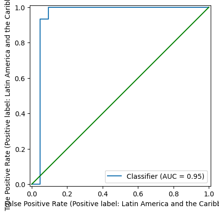

```python
# Create our ROC Curve plot
RocCurveDisplay.from_predictions(y_test2,
                                 probabilities[0],
                                 pos_label=categories[0])

# Draw a green line for 0
plt.plot([0, 1], [0, 1], color = 'g')
```

This block of code creates and ROC Curve, which compares the true positive rate and false positive rate. In other words, this curve is a visualization that helps with analyzing our model's performance. This can be accomplished by looking at the area of the green line underneath the classifer curve (the blue line in this case). Looking at the ROC Curve, our AUC (Area underneath curve) is 0.95, meaning that our model has a 95% confidence level, suggesting that our model performs very well.

# Step 6: Conclusion and Possible Next Stpes

Before running my models, I needed to visualize some correlations, so I used scatter plots. We found that household estimates had the biggest correlation to total combined food waste. Based on my findings, I ran a regression model to predict of the categories that measure food waste in tonnes (Household estimate, Retail estimate, and Food service estimate), as well as a country's region influence the total amount of food wasted. Using a Linear Regression model, using the separate categories (Household, retail, and food service estimates) measured in tonnes had little influence to the total amount of food wasted (measured in kg/capita). We also found that Sub-Saharan Africa wastes the most food. After finding that information, I validated the model with residuals, and RMSE and R2 score, a histogram of the residuals, and cross-validation to determine the accuracy and variation of our model. After validating this model, I learned that it performed poorly. After running my regression model, I decided to run a classificaiton model using the Naives Bayes method. After running this model, I decided to validate it using an ROC Curve, a confusion matrix, and cross-validation. Surprisingly, this model performed well, as the scores were close to 100% accurate with little variation. I learned that the classification model ran better than the regression model, most likely because the used the same units of measurement and because it was a different type of model. Going forward, I would change the unit of measurement from my regression model to be the same across predictor and target variables. I would also choose a different type of model, such as KNN Regression because it compares the data of a country's "neighbors".